# Image Analysis in Python: Segmentation via Selecting by Colour

⇦ Back

This tutorial looks at how to extract only the pixels in an image that fall within a certain part of the RGB colour model.

# 1 Python Packages

The code on this page uses the Numpy, Matplotlib and Pillow packages which can be installed from the terminal via the following:

```bash
# "python3.12" should correspond to the version of Python you are using
python3.12 -m pip install numpy
python3.12 -m pip install matplotlib
python3.12 -m pip install pillow
```

Once finished, import these packages into your Python script as follows:

```python
# NumPy is the fundamental package for scientific computing with Python
import numpy as np
# Matplotlib is for creating static, animated and interactive visualizations
from matplotlib import pyplot as plt
# Pillow is a fork of the Python Imaging Library (PIL) for image processing
from PIL import Image
```

Note that the Pillow package gets referred to as `PIL` in scripts. This is to preserve backwards compatibility with an older package called PIL (the Python Imaging Library).

If you’re on an Ubuntu machine or similar it’s possible that you will need to change some environment variables to be compatible with the Wayland system:

```python
# Access to underlying platform's identifying data
import platform
# os provides a portable way of using operating system dependent functionality
import os

# Check if you are on a Linux machine
if platform.system() == 'Linux':
    # Set the QT_QPA_PLATFORM environment variable to wayland
    os.environ['QT_QPA_PLATFORM'] = 'wayland'
    # Set the Matplotlib backend to one that is compatible with Wayland
    plt.switch_backend('Agg')
```

# 2 Import an Image

We’ll use an MRI image of the cross-section of an arm with the radial bone already highlighted in green:

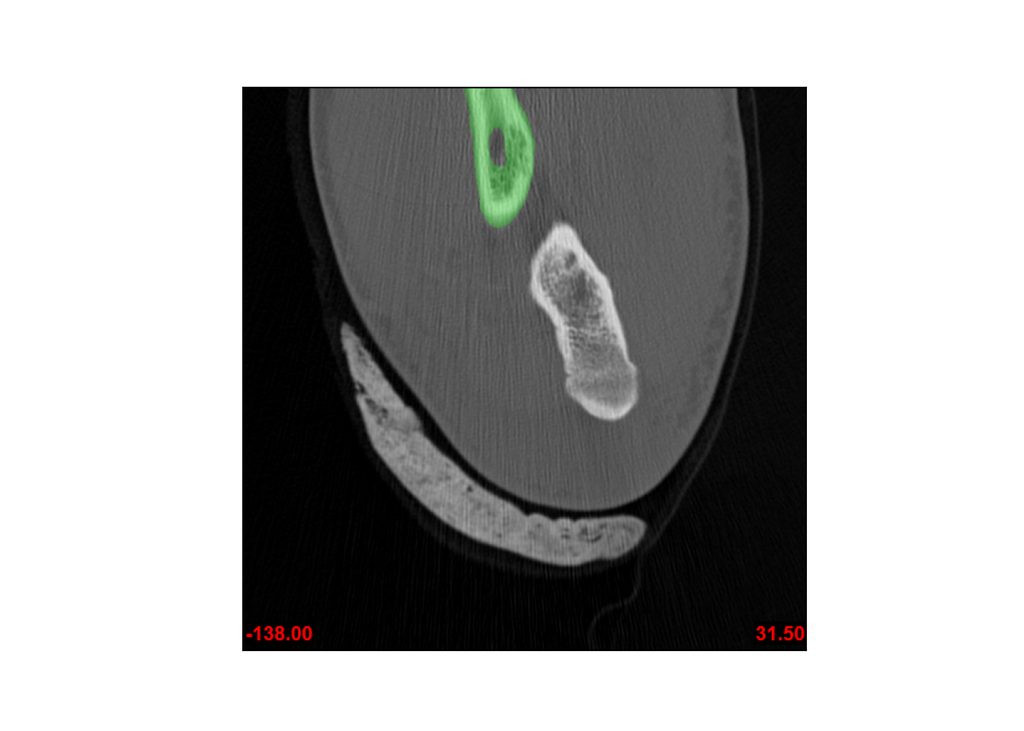

```python
# Import image
im = Image.open('original.bmp')
# Display image
plt.xticks([])
plt.yticks([])
plt.imshow(im)
```

What we want to do now is select only the green pixels in the image, but not all of these are the same shade of green. So what we actually need to do is select all green*-ish* pixels.

# 3 Search for Colours Within the RGB Colour Spectrum

```python
# Load the image (necessary in order to be able to change the pixel colours)
pix = im.load()
# Convert to RGB colours
rgb_im = im.convert('RGB')
# Get the size of the image
size_image = np.shape(im)
# Iterate over the rows in the image
for row in range(0, size_image[0]):
    # Iterate over the columns in the image
    for column in range(0, size_image[1]):
        # Get the RGB value of the pixel
        r, g, b = rgb_im.getpixel((column, row))
        # Is the pixel a certain shade?
        if 42 < r < 167 and 111 < g < 236 and 42 < b < 167 and g > r + 35:
            # Change the colour of the pixel
            pix[column, row] = (0, 0, 0)
        else:
            # Change the colour of the pixel
            pix[column, row] = (255, 255, 255)
```

# 4 Display the Result

Now that we have turned all the green pixels to black and all the other pixels to white, let’s confirm that only the radial bone is depicted:

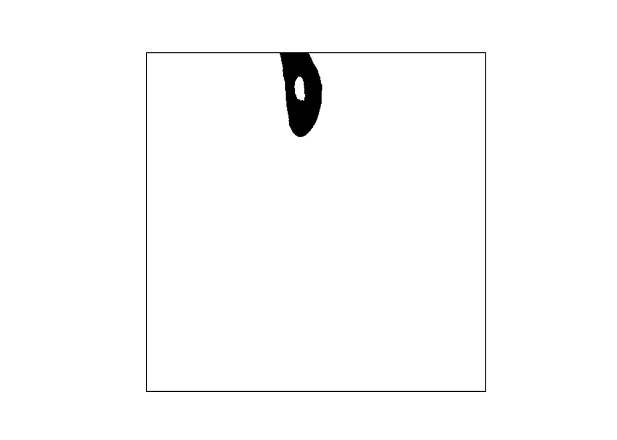

```python
plt.xticks([])
plt.yticks([])
plt.imshow(im)
```

Indeed, *only* the cross-section of the radial bone has been selected.

⇦ Back